# How Long Does It Take for the First Goal to Be Scored?

AUA CS 108 Statistics, Fall 2026 - Project 2 (Steps 1-5)

November 16, 2026

```r
# ---- Global settings: change them here only -------------------------------
DATA_FILE   <- "football_charts_matches.csv"
LEAGUE_CODE <- "premier"   # English Premier League (column 'league').
                           # NOTE: the column 'league_name' == "Premier League" is
                           # used by 5 different countries, so filter by 'league'.
C_MAX       <- 90          # observation window (minutes): regulation time
B_SIM       <- 2000        # simulation replications for Step 5.3
                           # (use >= 5000 for the coverage study in Step 6)
```

# 1 Problem description (Step 1)

**Practical question.** In a football match, after how many minutes is the first goal scored, and how likely is a match to have no goal at all? Is the “goal-scoring clock” memoryless (a constant scoring rate), or does the scoring rate grow as the match goes on?

**Parameters of interest.** Let $T$ be the time (in minutes) of the first goal. We model $T$ by a Weibull distribution with shape $k$ and scale $\lambda$. We want to estimate:

- the shape $k$ (is $k=1$, i.e. a constant scoring rate, or $k>1$, i.e. an increasing rate?);
- the scale $\lambda$ (a time scale, in minutes);
- the median time to the first goal, $m=\lambda(\ln 2)^{1/k}$;
- the probability of a goal-less match in regulation time, $p_0=P(T>C)=\exp\{-(C/\lambda)^k\}$ with $C=90$;
- the mean time to the first goal, $E[T]=\lambda\Gamma(1+1/k)$.

**Data-generating mechanism and assumptions.**

- One observation is one match. We assume that the matches are independent and identically distributed (i.i.d.) draws from the same Weibull model. This is an approximation: teams play several matches, and the strength of the teams differs. We discuss it in the limitations.
- **Right censoring.** We only observe the match for $C=90$ minutes. If no goal is scored in the window, we only know $T>C$. So we observe the pair $(Y_i,\delta_i)$ with $Y_i=\min(T_i,C)$ and $\delta_i=\mathbf 1\{T_i\le C\}$. This is the “censored lifetime” structure.
- The recorded times are integer minutes. We treat them as continuous (see limitations).

# 2 Model (Step 2)

## 2.1 The Weibull model

For $T\sim\text{Weibull}(k,\lambda)$, $k>0$, $\lambda>0$, support $t>0$:

$$f(t)=\frac{k}{\lambda}\left(\frac
t\lambda\right)^{k-1}e^{-(t/\lambda)^k},\qquad
S(t)=P(T>t)=e^{-(t/\lambda)^k},\qquad
h(t)=\frac{k}{\lambda}\left(\frac t\lambda\right)^{k-1}.$$

$$E[T]=\lambda\,\Gamma\!\left(1+\tfrac1k\right),\qquad
\text{Var}(T)=\lambda^2\left[\Gamma\!\left(1+\tfrac2k\right)-\Gamma^2\!\left(1+\tfrac1k\right)\right],\qquad
\text{median}=\lambda(\ln2)^{1/k}.$$

**Why Weibull?** $T$ is a waiting time until an event, so it is positive and right-skewed. The hazard $h(t)$ is the instantaneous scoring rate. For $k=1$ the hazard is constant (the exponential case, no memory). For $k>1$ the rate increases with time, which is plausible in football (tired defences, more risk-taking, substitutions). For $k<1$ it decreases. So the single parameter $k$ answers the question “does the scoring rate change during the match?”.

# 3 Dataset (Step 3)

## 3.1 Description

```r
raw <- read.csv(DATA_FILE, stringsAsFactors = FALSE)
str(raw)
```

```
## 'data.frame':    76991 obs. of  17 variables:
##  $ league         : chr  "algir1" "algir1" "algir1" "algir1" ...
##  $ league_name    : chr  "Ligue 1" "Ligue 1" "Ligue 1" "Ligue 1" ...
##  $ country        : chr  "Algeria" "Algeria" "Algeria" "Algeria" ...
##  $ season         : chr  "2023-2024" "2023-2024" "2023-2024" "2023-2024" ...
##  $ match_date     : chr  "2023-09-15" "2023-09-15" "2023-09-15" "2023-09-16" ...
##  $ time           : chr  "15:00" "15:00" "18:00" "15:00" ...
##  $ kickoff_utc    : chr  "2023-09-15T15:00:00Z" "2023-09-15T15:00:00Z" "2023-09-15T18:00:00Z" "2023-09-16T15:00:00Z" ...
##  $ home_team      : chr  "Khenchela" "El Bayadh" "ASO Chlef" "Magra" ...
##  $ away_team      : chr  "ES Setif" "Constantine" "Oran" "Kabylie" ...
##  $ ht_result      : chr  "0:0" "1:0" "0:0" "0:1" ...
##  $ ft_result      : chr  "1:0" "1:0" "2:0" "0:1" ...
##  $ home_goals     : int  1 1 2 0 4 1 0 2 2 1 ...
##  $ away_goals     : int  0 0 0 1 0 0 0 2 1 1 ...
##  $ total_goals    : int  1 1 2 1 4 1 0 4 3 2 ...
##  $ result         : chr  "H" "H" "H" "A" ...
##  $ first_goal_time: num  61 41 47 44 11 31 NA 12 15 5 ...
##  $ all_goal_times : chr  "61" "41" "47,62" "44" ...
```

```r
cat("Rows:", nrow(raw), " Leagues:", length(unique(raw$league)),
    " Countries:", length(unique(raw$country)), "\n")
```

```
## Rows: 76991  Leagues: 92  Countries: 42
```

## 3.2 Data preparation and audit

We do **not** modify anything silently. The audit below lists every issue in the selected subset, and then the exact rules we apply.

```r
sub <- raw[raw$league == LEAGUE_CODE & grepl("-", raw$season), ]

# first goal time implied by all_goal_times (when it can be parsed)
first_from_list <- suppressWarnings(as.numeric(sub("^([0-9.]+).*$", "\\1", sub$all_goal_times)))

audit <- data.frame(
  check = c(
    "Matches in subset",
    "Duplicated matches (same season, date, teams)",
    "Missing kickoff time",
    "0-0 matches (first_goal_time is NA): treated as censored",
    "Matches with goals > 0 but first_goal_time missing",
    "Matches with 0 goals but a first_goal_time",
    "First goal after minute C_MAX (stoppage time): treated as censored at C_MAX",
    "Non-integer first_goal_time",
    "all_goal_times marked 'Not found'",
    "first_goal_time differs from first element of all_goal_times"),
  count = c(
    nrow(sub),
    sum(duplicated(sub[, c("season", "match_date", "home_team", "away_team")])),
    sum(is.na(sub$time)),
    sum(sub$total_goals == 0 & is.na(sub$first_goal_time)),
    sum(sub$total_goals > 0 & is.na(sub$first_goal_time)),
    sum(sub$total_goals == 0 & !is.na(sub$first_goal_time)),
    sum(sub$first_goal_time > C_MAX, na.rm = TRUE),
    sum(sub$first_goal_time %% 1 != 0, na.rm = TRUE),
    sum(sub$all_goal_times == "Not found", na.rm = TRUE),
    sum(!is.na(first_from_list) & !is.na(sub$first_goal_time) &
          first_from_list != sub$first_goal_time)))
knitr::kable(audit)
```

| check | count |
| --- | --- |
| Matches in subset | 1140 |
| Duplicated matches (same season, date, teams) | 0 |
| Missing kickoff time | 0 |
| 0-0 matches (first_goal_time is NA): treated as censored | 54 |
| Matches with goals > 0 but first_goal_time missing | 0 |
| Matches with 0 goals but a first_goal_time | 0 |
| First goal after minute C_MAX (stoppage time): treated as censored at C_MAX | 10 |
| Non-integer first_goal_time | 0 |
| all_goal_times marked ‘Not found’ | 0 |
| first_goal_time differs from first element of all_goal_times | 0 |

**Rules applied (and why).**

1. A match with `total_goals == 0` has `first_goal_time = NA` because no goal happened. This is not a missing value: it is a **right-censored** observation, $Y=C$, $\delta=0$.
2. A match with goals but no recorded time would be a genuine missing value, so it is dropped (the count is in the audit; in the Premier League it is expected to be 0).
3. A first goal after minute $C=90$ (stoppage time) is treated as censored at $C$ ($Y=C,\ \delta=0$). Otherwise a match with a goal at minute 92 would be an event at 92, while a 0-0 match, which also lasts about 95 minutes, would be cut at 90. Rule 3 makes the window the same for every match. The estimand is “time to the first goal **within regulation time**”.
4. If a match appears twice (same season, date and teams), the second copy is removed. The number of such rows is reported in the audit above.

```r
make_data <- function(df, C) {
  df <- df[!duplicated(df[, c("season", "match_date", "home_team", "away_team")]), ]
  df <- df[df$total_goals == 0 | !is.na(df$first_goal_time), ]   # rule 2
  ev <- df$total_goals > 0 & df$first_goal_time <= C
  ev[is.na(ev)] <- FALSE                                         # 0-0 matches
  data.frame(t = ifelse(ev, df$first_goal_time, C),
             delta = as.integer(ev),
             season = df$season, home = df$home_team, away = df$away_team,
             date = df$match_date)
}
dat <- make_data(sub, C_MAX)
n <- nrow(dat); d <- sum(dat$delta)
cat("n =", n, " observed first goals d =", d,
    " censored =", n - d, sprintf("(%.1f%%)\n", 100 * (n - d) / n))
```

```
## n = 1140  observed first goals d = 1076  censored = 64 (5.6%)
```

```r
summary(dat$t[dat$delta == 1])
```

```
##    Min. 1st Qu.  Median    Mean 3rd Qu.    Max.
##    1.00   12.00   25.00   29.47   44.00   90.00
```

**Check of the i.i.d. assumption.** Matches are not a time series in the usual sense, but the same teams repeat, and a team’s attacking strength is persistent. We look at the stability across seasons in Step 5 and discuss the effect in the limitations.

**Rounding/heaping of the minutes.** The first goal times are integer minutes, and the stoppage-time goals of the first half are recorded as minutes 46, 47, … (pooled over all leagues):

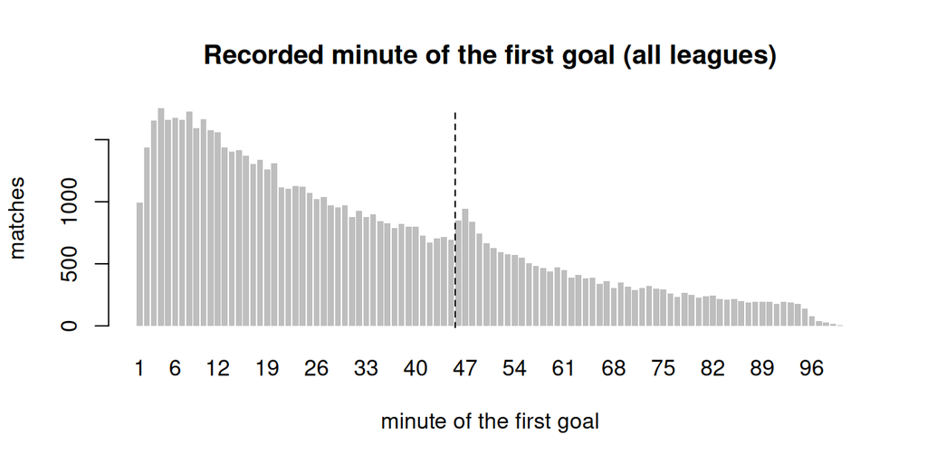

```r
x <- raw$first_goal_time[!is.na(raw$first_goal_time)]
tab <- tabulate(ceiling(x[x <= 100]), nbins = 100)
barplot(tab, names.arg = 1:100, xlab = "minute of the first goal", ylab = "matches",
        main = "Recorded minute of the first goal (all leagues)", border = NA)
abline(v = 0.2 + 1.2 * 45, lty = 2)
```

The bump after minute 45 is first-half stoppage time. It is a measurement artefact: we mention it in the limitations.

# 4 Likelihoods, fitting and model comparison (Steps 2 and 4)

With observations $(y_i,\delta_i)$, the likelihood for a distribution with density $f$ and survival function $S$ is

$$L(\theta)=\prod_{i=1}^n
f(y_i;\theta)^{\delta_i}\,S(y_i;\theta)^{1-\delta_i}.$$

Events contribute through the density, censored matches through the survival function.

```r
# All parameters are on the log scale (eta) to keep them positive and the optimisation stable.
nll_weibull <- function(eta, t, delta) {
  k <- exp(eta[1]); lam <- exp(eta[2])
  -(sum(delta * (log(k) - log(lam) + (k - 1) * (log(t) - log(lam)))) - sum((t / lam)^k))
}
nll_exp <- function(eta, t, delta) {            # exponential: S(t)=exp(-t/lambda)
  lam <- exp(eta[1])
  -(-sum(delta) * log(lam) - sum(t) / lam)
}
nll_gamma <- function(eta, t, delta) {          # shape a, rate b
  a <- exp(eta[1]); b <- exp(eta[2])
  -(sum(delta * dgamma(t, a, b, log = TRUE)) +
      sum((1 - delta) * pgamma(t, a, b, lower.tail = FALSE, log.p = TRUE)))
}
nll_lnorm <- function(eta, t, delta) {          # meanlog mu, sdlog sigma
  mu <- eta[1]; s <- exp(eta[2])
  -(sum(delta * dlnorm(t, mu, s, log = TRUE)) +
      sum((1 - delta) * plnorm(t, mu, s, lower.tail = FALSE, log.p = TRUE)))
}

ev_t <- dat$t[dat$delta == 1]
fit_w <- optim(c(0, log(mean(dat$t))), nll_weibull, t = dat$t, delta = dat$delta,
               method = "BFGS", control = list(reltol = 1e-12, maxit = 1000))
fit_e <- optim(log(mean(dat$t)), nll_exp, t = dat$t, delta = dat$delta,
               method = "BFGS", control = list(reltol = 1e-12))
m <- mean(ev_t); v <- var(ev_t)
fit_g <- optim(log(c(m^2 / v, m / v)), nll_gamma, t = dat$t, delta = dat$delta,
               method = "BFGS", control = list(reltol = 1e-12, maxit = 1000))
fit_l <- optim(c(mean(log(ev_t)), log(sd(log(ev_t)))), nll_lnorm, t = dat$t, delta = dat$delta,
               method = "BFGS", control = list(reltol = 1e-12, maxit = 1000))

comp <- data.frame(
  model  = c("Exponential", "Weibull", "Gamma", "Log-normal"),
  params = c(1, 2, 2, 2),
  logLik = -c(fit_e$value, fit_w$value, fit_g$value, fit_l$value))
comp$AIC <- -2 * comp$logLik + 2 * comp$params
comp$BIC <- -2 * comp$logLik + log(n) * comp$params
comp$dAIC <- comp$AIC - min(comp$AIC)
knitr::kable(comp, digits = 2)
```

| model | params | logLik | AIC | BIC | dAIC |
| --- | --- | --- | --- | --- | --- |
| Exponential | 1 | -4896.23 | 9794.45 | 9799.49 | 37.44 |
| Weibull | 2 | -4877.55 | 9759.09 | 9769.17 | 2.08 |
| Gamma | 2 | -4876.51 | 9757.02 | 9767.09 | 0.00 |
| Log-normal | 2 | -4921.20 | 9846.40 | 9856.48 | 89.38 |

**How to read it.** A smaller AIC/BIC is better (AIC = $-2\ell+2p$ penalises the number of parameters $p$). Differences of AIC smaller than about 2 mean that the models are practically equivalent.

# 5 Relevance of the model to the data (Step 4)

```r
k_w <- exp(fit_w$par[1]); lam_w <- exp(fit_w$par[2])
lam_e <- exp(fit_e$par)
a_g <- exp(fit_g$par[1]); b_g <- exp(fit_g$par[2])
mu_l <- fit_l$par[1]; s_l <- exp(fit_l$par[2])

# Kaplan-Meier estimator (handles ties; events are placed before censorings at the same time)
km <- function(t, delta) {
  o <- order(t, -delta); ts <- t[o]; ds <- delta[o]
  N <- length(ts)
  S <- cumprod(1 - ds / (N - seq_len(N) + 1))
  keep <- ds == 1 & !duplicated(ts, fromLast = TRUE)
  data.frame(time = ts[keep], surv = S[keep])
}
km_dat <- km(dat$t, dat$delta)
```

## 5.1 Graphical methods

**(a) Kaplan-Meier survival curve against the fitted survival functions.** The Kaplan-Meier estimate is the nonparametric estimate of $S(t)=P(T>t)$, valid with censoring. If the model is good, its curve follows the KM curve.

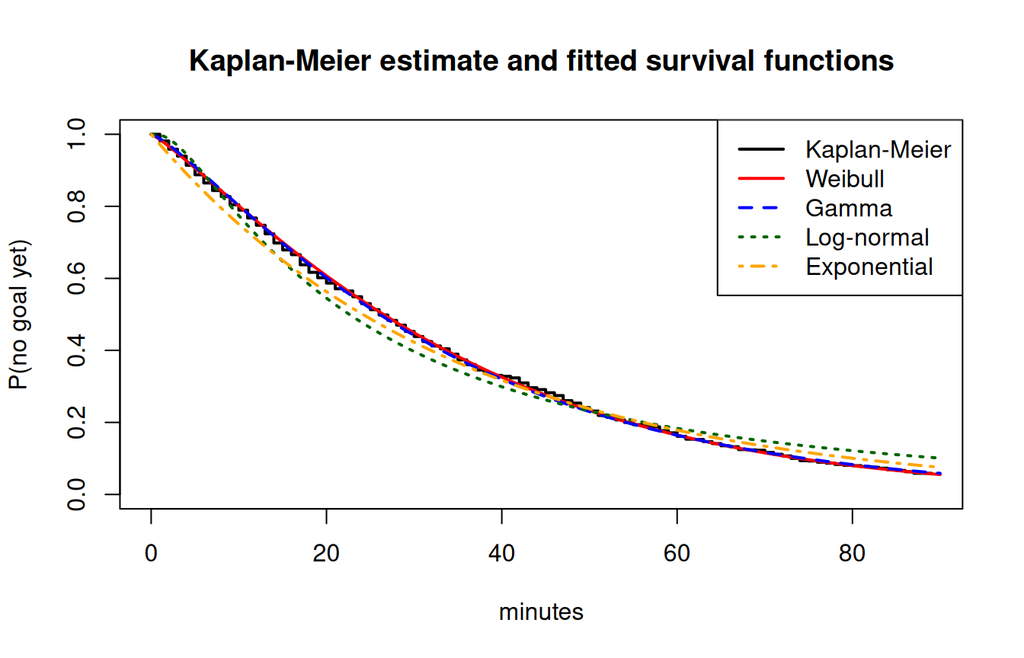

```r
tt <- seq(0, C_MAX, length.out = 300)
plot(c(0, km_dat$time), c(1, km_dat$surv), type = "s", lwd = 2,
     xlab = "minutes", ylab = "P(no goal yet)", ylim = c(0, 1),
     main = "Kaplan-Meier estimate and fitted survival functions")
lines(tt, exp(-(tt / lam_w)^k_w), col = "red", lwd = 2)
lines(tt, pgamma(tt, a_g, b_g, lower.tail = FALSE), col = "blue", lwd = 2, lty = 2)
lines(tt, plnorm(tt, mu_l, s_l, lower.tail = FALSE), col = "darkgreen", lwd = 2, lty = 3)
lines(tt, exp(-tt / lam_e), col = "orange", lwd = 2, lty = 4)
legend("topright", c("Kaplan-Meier", "Weibull", "Gamma", "Log-normal", "Exponential"),
       col = c("black", "red", "blue", "darkgreen", "orange"), lwd = 2, lty = c(1, 1, 2, 3, 4))
```

**(b) Observed counts against the counts expected under the Weibull model** (the histogram analogue for censored data). In each 5-minute bin, the expected number of first goals is $n\,[F(b_j)-F(b_{j-1})]$. The last bar is “no goal in the window”.

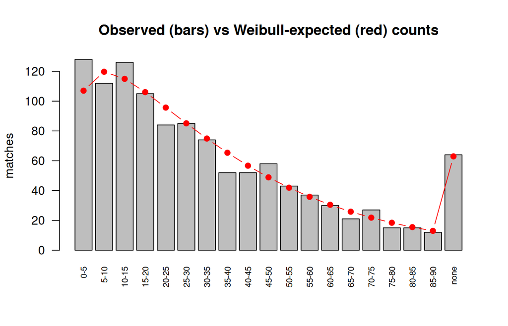

```r
brk <- sort(unique(c(seq(0, C_MAX, by = 5), C_MAX)))
obs <- as.vector(table(cut(ev_t, brk, include.lowest = TRUE)))
Fw  <- pweibull(brk, k_w, lam_w)
exp_ev <- n * diff(Fw)
obs_all <- c(obs, n - d)
exp_all <- c(exp_ev, n * (1 - Fw[length(Fw)]))
lab <- c(paste0(brk[-length(brk)], "-", brk[-1]), "none")
bp <- barplot(obs_all, names.arg = lab, las = 2, cex.names = 0.7,
              ylab = "matches", main = "Observed (bars) vs Weibull-expected (red) counts")
points(bp, exp_all, col = "red", pch = 19, type = "b")
```

**(c) Weibull plot.** Since $\log\{-\log S(t)\}=k\log t-k\log\lambda$, the points $(\log t,\ \log\{-\log\hat S_{KM}(t)\})$ should lie on a straight line with slope $k$ if the Weibull model is correct.

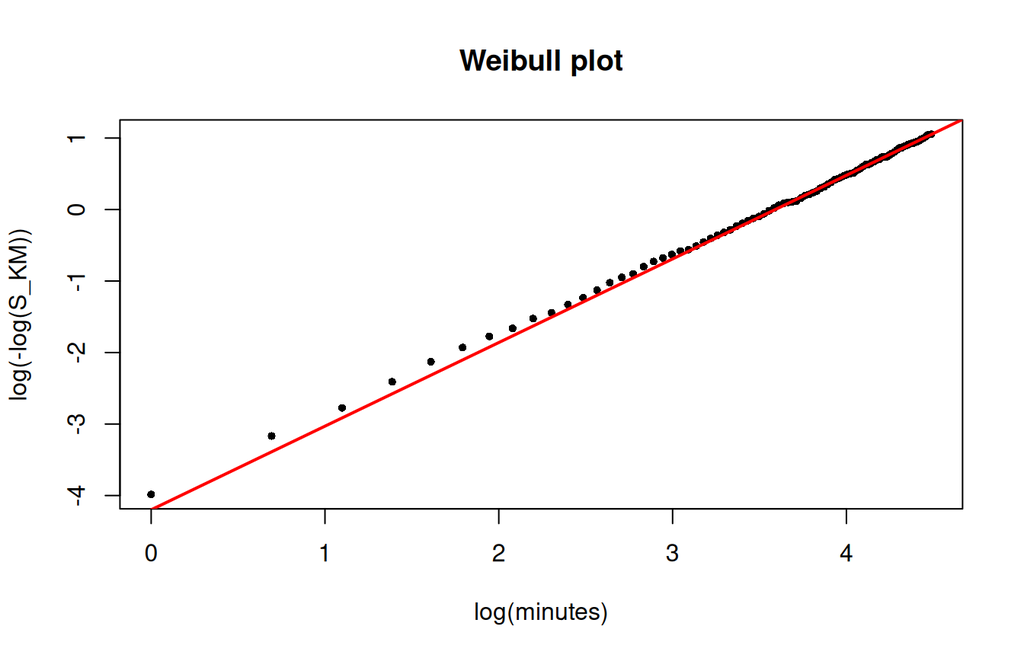

```r
ok <- km_dat$surv > 0 & km_dat$surv < 1
plot(log(km_dat$time[ok]), log(-log(km_dat$surv[ok])), pch = 16, cex = 0.7,
     xlab = "log(minutes)", ylab = "log(-log(S_KM))", main = "Weibull plot")
abline(a = -k_w * log(lam_w), b = k_w, col = "red", lwd = 2)
```

**(d) QQ plot.** With censoring, the plain QQ plot uses only the observed first goals $y_{(1)}\le\dots\le y_{(d)}$. Those are draws from the Weibull distribution **truncated to $[0,C]$**, whose quantile function is $F^{-1}(u\,F(C))$. So we plot the observed times against these quantiles at $u_i=(i-0.5)/d$.

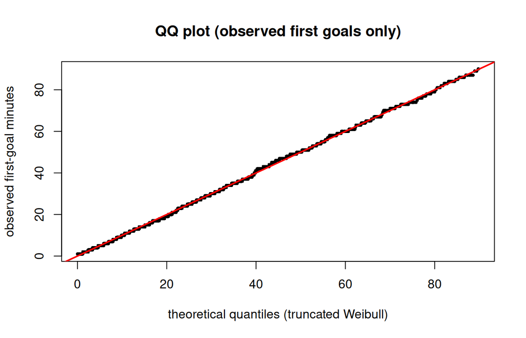

```r
u <- (seq_len(d) - 0.5) / d
q_theo <- qweibull(u * pweibull(C_MAX, k_w, lam_w), k_w, lam_w)
plot(q_theo, sort(ev_t), pch = 16, cex = 0.6,
     xlab = "theoretical quantiles (truncated Weibull)", ylab = "observed first-goal minutes",
     main = "QQ plot (observed first goals only)")
abline(0, 1, col = "red", lwd = 2)
```

The horizontal “steps” are caused by the integer minutes.

## 5.2 Formal tests (optional, they complement the plots)

**Chi-square goodness-of-fit test on the bins of plot (b).**

- $H_0$: the data come from the fitted Weibull (with censoring); $H_1$: they do not.
- Statistic: $X^2=\sum_j (O_j-E_j)^2/E_j$ over the $m$ bins (including the “no goal” bin).
- Under $H_0$ it is approximately $\chi^2$. Because the parameters were estimated from the ungrouped data, its null distribution lies between $\chi^2_{m-1-2}$ and $\chi^2_{m-1}$, so we report both p-values.
- A small p-value is evidence against the model. A large p-value only says that we found no evidence against it. With a large $n$, a small p-value can also come from a practically irrelevant deviation.

```r
X2 <- sum((obs_all - exp_all)^2 / exp_all); mbin <- length(obs_all)
data.frame(X2 = X2, bins = mbin,
           p_df_m_minus_3 = pchisq(X2, mbin - 3, lower.tail = FALSE),
           p_df_m_minus_1 = pchisq(X2, mbin - 1, lower.tail = FALSE),
           min_expected = min(exp_all))
```

| X2 | bins | p_df_m_minus_3 | p_df_m_minus_1 | min_expected |
| --- | --- | --- | --- | --- |
| 14.87743 | 19 | 0.5336337 | 0.6703657 | 12.9662 |

**Likelihood-ratio test of $H_0:k=1$ (exponential) against $H_1$: Weibull.** The models are nested. The statistic is $2(\ell_{Weibull}-\ell_{exp})\overset{H_0}{\approx}\chi^2_1$.

```r
LR <- 2 * (-fit_w$value + fit_e$value)
data.frame(LR = LR, p_value = pchisq(LR, 1, lower.tail = FALSE))
```

| LR | p_value |
| --- | --- |
| 37.36093 | 9.816926e-10 |

**Stability across seasons** (a rough check of the i.i.d. assumption) uses the estimator derived in the next section, so the table is given there (chunk `by-season`).

# 6 Estimators and their properties (Step 5)

## 6.1 Construction of the estimators

### 6.1.1 Maximum likelihood estimator (MLE)

The log-likelihood of the Weibull model with censoring, with $d=\sum\delta_i$ the number of observed first goals, is

$$\ell(k,\lambda)=d\log
k-dk\log\lambda+(k-1)\sum_i\delta_i\log y_i-\lambda^{-k}\sum_i y_i^k
.$$

*Derivation.* For an event, $\log f(y)=\log k-\log\lambda+(k-1)\log(y/\lambda)-(y/\lambda)^k$. For a censored match, $\log S(y)=-(y/\lambda)^k$. Summing over all matches (events with weight $\delta_i$, all matches for the $-(y/\lambda)^k$ term) gives the formula.

**Score equation for $\lambda$.** $\ \partial\ell/\partial\lambda=-dk/\lambda+k\lambda^{-k-1}\sum y_i^k=0$, so for a fixed $k$

$$\hat\lambda(k)=\left(\frac{\sum_i
y_i^k}{d}\right)^{1/k}.$$

**Profile likelihood for $k$.** Substituting $\hat\lambda(k)$ back, $\ell_p(k)=d\log k-d\log\!\big(\sum y_i^k/d\big)+(k-1)\sum\delta_i\log y_i-d$, and $\ell_p'(k)=0$ gives

$$g(k)=\frac1k+\frac{\sum_i\delta_i\log
y_i}{d}-\frac{\sum_i y_i^k\log y_i}{\sum_i y_i^k}=0 .$$

This equation has **no closed-form solution**. Properties used for the numerical solution: $g(k)\to+\infty$ as $k\to0^+$, and $g(k)<0$ for large $k$ (the last term tends to $\log\max y_i$, which exceeds the mean log of the observed times). So a root is bracketed, and we solve it by Brent’s method (`uniroot`), then compute $\hat\lambda=\hat\lambda(\hat k)$.

```r
mle_weibull <- function(t, delta) {
  d <- sum(delta); slog <- sum(delta * log(t)); tmax <- max(t)
  g <- function(k) {
    w <- (t / tmax)^k                      # rescaling avoids overflow; the ratio is unchanged
    1 / k + slog / d - sum(w * log(t)) / sum(w)
  }
  k <- uniroot(g, c(0.01, 50), tol = 1e-12)$root
  lam <- tmax * (sum((t / tmax)^k) / d)^(1 / k)
  c(k = k, lambda = lam)
}
mle <- mle_weibull(dat$t, dat$delta)
mle
```

```
##         k    lambda
##  1.169526 36.251182
```

**Check of the numerical solution.** (i) the score $g(\hat k)$ should be about 0, (ii) the gradient of the log-likelihood should vanish, (iii) the result should coincide with the direct numerical maximisation by `optim` above.

```r
eta_hat <- log(mle)
grad <- sapply(1:2, function(j) {
  e <- c(0, 0); e[j] <- 1e-6
  -(nll_weibull(eta_hat + e, dat$t, dat$delta) - nll_weibull(eta_hat - e, dat$t, dat$delta)) / 2e-6
})
data.frame(source = c("profile + uniroot", "direct optim (BFGS)"),
           k = c(mle[1], k_w), lambda = c(mle[2], lam_w),
           max_abs_gradient = c(max(abs(grad)), NA), row.names = NULL)
```

| source | k | lambda | max_abs_gradient |
| --- | --- | --- | --- |
| profile + uniroot | 1.169526 | 36.25118 | 0 |
| direct optim (BFGS) | 1.169527 | 36.25122 | NA |

### 6.1.2 Other estimators (for comparison)

**Method of moments (naive, ignores censoring).** For complete data, $\text{CV}^2=\text{Var}(T)/E[T]^2=\Gamma(1+2/k)/\Gamma^2(1+1/k)-1$ depends on $k$ only. We equate it to the sample $s^2/\bar y^2$ of the observed first goals, solve for $\hat k$, and take $\hat\lambda=\bar y/\Gamma(1+1/\hat k)$. This uses only the matches with a goal, so it ignores the censoring: **it is expected to be biased**, and we use the simulation to show how much.

**Weibull-plot (least-squares) estimator.** Regress $\log\{-\log\hat S_{KM}(y)\}$ on $\log y$ over the observed times: the slope estimates $k$ and the intercept estimates $-k\log\lambda$.

```r
mom_weibull <- function(t, delta) {
  y <- t[delta == 1]
  if (length(y) < 3) return(c(k = NA, lambda = NA))
  cv2 <- var(y) / mean(y)^2
  f <- function(k) gamma(1 + 2 / k) / gamma(1 + 1 / k)^2 - 1 - cv2
  k <- uniroot(f, c(0.05, 100), tol = 1e-10)$root
  c(k = k, lambda = mean(y) / gamma(1 + 1 / k))
}
wp_weibull <- function(t, delta) {
  kmx <- km(t, delta); kmx <- kmx[kmx$surv > 0 & kmx$surv < 1, ]
  if (nrow(kmx) < 3) return(c(k = NA, lambda = NA))
  b <- coef(lm(log(-log(kmx$surv)) ~ log(kmx$time)))
  c(k = unname(b[2]), lambda = unname(exp(-b[1] / b[2])))
}
rbind(MLE = mle, MoM_naive = mom_weibull(dat$t, dat$delta), WeibullPlot = wp_weibull(dat$t, dat$delta))
```

```
##                    k   lambda
## MLE         1.169526 36.25118
## MoM_naive   1.360353 32.18531
## WeibullPlot 1.117312 35.32521
```

## 6.2 Properties of the estimators

**No exact finite-sample formulas.** For the Weibull model with censoring, $\hat k$ and $\hat\lambda$ do not have closed forms, so unbiasedness and the variance cannot be derived exactly. We therefore use (a) the large-sample theory and (b) simulation (Section 5.3).

**Large-sample theory (what we can say analytically).** The model is regular (the support does not depend on the parameters), so the MLE is consistent, asymptotically normal and asymptotically efficient:
$$\hat\theta\ \approx\
N\big(\theta,\ I_n(\theta)^{-1}\big),\qquad
I_n(\theta)=n\,I_1(\theta),$$
where $I(\theta)=-E[\partial^2\ell/\partial\theta\,\partial\theta^\top]$ is the Fisher information. The Cramer-Rao bound $I_n^{-1}$ is attained asymptotically. We estimate it by the **observed information** $-\partial^2\ell/\partial\theta^\top\partial\theta$ at $\hat\theta$ (numerical Hessian), working on the log-scale $\eta=(\log k,\log\lambda)$, and then use the **delta method** for any function $\phi(\eta)$ of the parameters:
$$\widehat{\text{se}}(\phi(\hat\eta))=\sqrt{\nabla\phi^\top\,\hat
V\,\nabla\phi},\qquad \hat
V=\big(-\partial^2\ell/\partial\eta\,\partial\eta^\top\big)^{-1}\big|_{\hat\eta}.$$

```r
num_jac <- function(f, x, h = 1e-5) {
  f0 <- f(x); J <- matrix(0, length(f0), length(x))
  for (j in seq_along(x)) {
    e <- rep(0, length(x)); e[j] <- h
    J[, j] <- (f(x + e) - f(x - e)) / (2 * h)
  }
  J
}
# quantities of interest as functions of eta = (log k, log lambda)
g_fun <- function(eta, C) {
  k <- exp(eta[1]); lam <- exp(eta[2])
  c(k = k, lambda = lam,
    median = lam * log(2)^(1 / k),
    p0_no_goal = exp(-(C / lam)^k),
    mean = lam * gamma(1 + 1 / k))
}
fit_weib <- function(t, delta, C) {
  mle <- mle_weibull(t, delta); eta <- log(mle)
  V <- solve(optimHess(eta, nll_weibull, t = t, delta = delta))
  J <- num_jac(function(e) g_fun(e, C), eta)
  est <- g_fun(eta, C)
  list(table = data.frame(parameter = names(est), estimate = unname(est),
                          se = sqrt(diag(J %*% V %*% t(J))), row.names = NULL),
       eta = eta, V = V, loglik = -nll_weibull(eta, t, delta))
}
```

## 6.3 Properties by simulation

We fix the true parameters at the estimates from the real data, simulate $B$ samples for several sample sizes $n$ (including the real $n$), apply the same censoring at $C$, and compute the estimators. For each estimator we estimate the bias, the standard deviation, and the MSE $=\text{bias}^2+\text{Var}$.

```r
k0 <- unname(mle["k"]); lam0 <- unname(mle["lambda"])

sim_weibull <- function(n, k, lam, C) {
  x <- rweibull(n, k, lam)
  list(t = pmin(x, C), delta = as.integer(x <= C))
}
safe <- function(f, t, delta) tryCatch(f(t, delta), error = function(e) c(k = NA, lambda = NA))

n_grid <- sort(unique(c(10, 30, 100, 500, n)))
est_names <- c("MLE", "MoM_naive", "WeibullPlot")

sim_one <- function(nn) {
  out <- matrix(NA_real_, B_SIM, 6)
  for (b in 1:B_SIM) {
    s <- sim_weibull(nn, k0, lam0, C_MAX)
    if (sum(s$delta) < 3) next
    out[b, ] <- c(safe(mle_weibull, s$t, s$delta),
                  safe(mom_weibull, s$t, s$delta),
                  safe(wp_weibull, s$t, s$delta))
  }
  colnames(out) <- c("k_MLE", "lam_MLE", "k_MoM_naive", "lam_MoM_naive", "k_WeibullPlot", "lam_WeibullPlot")
  out
}
sim <- lapply(n_grid, sim_one); names(sim) <- n_grid

summ <- do.call(rbind, lapply(as.character(n_grid), function(nn) {
  do.call(rbind, lapply(est_names, function(en) {
    do.call(rbind, lapply(c(k = "k", lambda = "lam"), function(pn) {
      x <- sim[[nn]][, paste0(pn, "_", en)]
      true <- if (pn == "k") k0 else lam0
      x <- x[is.finite(x)]
      data.frame(n = as.integer(nn), estimator = en,
                 parameter = ifelse(pn == "k", "k", "lambda"),
                 bias = mean(x) - true, sd = sd(x),
                 MSE = mean((x - true)^2),
                 mean_ratio = mean(x) / true, n_valid = length(x))
    }))
  }))
}))
rownames(summ) <- NULL
knitr::kable(summ, digits = 4)
```

| n | estimator | parameter | bias | sd | MSE | mean_ratio | n_valid |
| --- | --- | --- | --- | --- | --- | --- | --- |
| 10 | MLE | k | 0.1668 | 0.4073 | 0.1937 | 1.1426 | 2000 |
| 10 | MLE | lambda | 0.9990 | 11.1642 | 125.5752 | 1.0276 | 2000 |
| 10 | MoM_naive | k | 0.3047 | 0.3902 | 0.2450 | 1.2606 | 2000 |
| 10 | MoM_naive | lambda | -3.9527 | 8.3867 | 85.9246 | 0.8910 | 2000 |
| 10 | WeibullPlot | k | -0.0937 | 0.4032 | 0.1713 | 0.9199 | 2000 |
| 10 | WeibullPlot | lambda | -2.4450 | 11.1907 | 131.1470 | 0.9326 | 2000 |
| 30 | MLE | k | 0.0427 | 0.1975 | 0.0408 | 1.0365 | 2000 |
| 30 | MLE | lambda | -0.0331 | 6.0573 | 36.6733 | 0.9991 | 2000 |
| 30 | MoM_naive | k | 0.2230 | 0.1932 | 0.0871 | 1.1907 | 2000 |
| 30 | MoM_naive | lambda | -4.1802 | 4.7688 | 40.2044 | 0.8847 | 2000 |
| 30 | WeibullPlot | k | -0.0816 | 0.2306 | 0.0598 | 0.9303 | 2000 |
| 30 | WeibullPlot | lambda | -0.9276 | 6.5816 | 44.1563 | 0.9744 | 2000 |
| 100 | MLE | k | 0.0148 | 0.1007 | 0.0104 | 1.0127 | 2000 |
| 100 | MLE | lambda | 0.1275 | 3.3367 | 11.1440 | 1.0035 | 2000 |
| 100 | MoM_naive | k | 0.2152 | 0.1006 | 0.0564 | 1.1840 | 2000 |
| 100 | MoM_naive | lambda | -3.8596 | 2.7238 | 22.3118 | 0.8935 | 2000 |
| 100 | WeibullPlot | k | -0.0472 | 0.1276 | 0.0185 | 0.9596 | 2000 |
| 100 | WeibullPlot | lambda | 0.1271 | 3.6127 | 13.0613 | 1.0035 | 2000 |
| 500 | MLE | k | 0.0039 | 0.0428 | 0.0018 | 1.0034 | 2000 |
| 500 | MLE | lambda | -0.0308 | 1.5348 | 2.3554 | 0.9992 | 2000 |
| 500 | MoM_naive | k | 0.2073 | 0.0440 | 0.0449 | 1.1773 | 2000 |
| 500 | MoM_naive | lambda | -3.8900 | 1.2302 | 16.6445 | 0.8927 | 2000 |
| 500 | WeibullPlot | k | -0.0180 | 0.0587 | 0.0038 | 0.9846 | 2000 |
| 500 | WeibullPlot | lambda | 0.0970 | 1.6626 | 2.7724 | 1.0027 | 2000 |
| 1140 | MLE | k | 0.0019 | 0.0284 | 0.0008 | 1.0017 | 2000 |
| 1140 | MLE | lambda | 0.0008 | 0.9629 | 0.9267 | 1.0000 | 2000 |
| 1140 | MoM_naive | k | 0.2069 | 0.0288 | 0.0437 | 1.1769 | 2000 |
| 1140 | MoM_naive | lambda | -3.8733 | 0.7603 | 15.5803 | 0.8932 | 2000 |
| 1140 | WeibullPlot | k | -0.0108 | 0.0400 | 0.0017 | 0.9908 | 2000 |
| 1140 | WeibullPlot | lambda | 0.1002 | 1.0305 | 1.0714 | 1.0028 | 2000 |

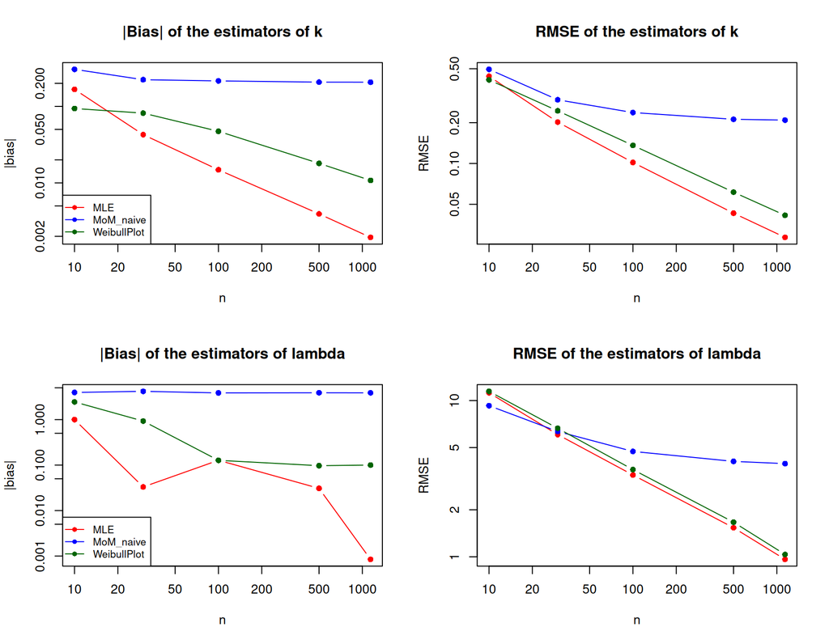

```r
cols <- c(MLE = "red", MoM_naive = "blue", WeibullPlot = "darkgreen")
par(mfrow = c(2, 2))
for (pn in c("k", "lambda")) {
  s1 <- summ[summ$parameter == pn, ]
  plot(NA, xlim = range(n_grid), ylim = range(abs(s1$bias)[abs(s1$bias) > 0]), log = "xy",
       xlab = "n", ylab = "|bias|", main = paste("|Bias| of the estimators of", pn))
  for (en in est_names) { z <- s1[s1$estimator == en, ]; lines(z$n, abs(z$bias), type = "b", col = cols[en], pch = 16) }
  legend("bottomleft", est_names, col = cols, pch = 16, lty = 1, cex = 0.8)
  plot(NA, xlim = range(n_grid), ylim = range(sqrt(s1$MSE)), log = "xy",
       xlab = "n", ylab = "RMSE", main = paste("RMSE of the estimators of", pn))
  for (en in est_names) { z <- s1[s1$estimator == en, ]; lines(z$n, sqrt(z$MSE), type = "b", col = cols[en], pch = 16) }
}
```

```r
par(mfrow = c(1, 1))
```

**Comparison of the simulated SD of the MLE with the asymptotic theory.** The expected information per observation, $I_1$, is approximated by the Hessian of the negative log-likelihood at the true parameters for a very large simulated sample. Then $\text{sd}(\hat\eta)\approx\sqrt{(I_1^{-1})_{jj}/n}$, and by the delta method $\text{sd}(\hat k)\approx k\,\text{sd}(\hat\eta_1)$, $\text{sd}(\hat\lambda)\approx\lambda\,\text{sd}(\hat\eta_2)$.

```r
big <- sim_weibull(2e5, k0, lam0, C_MAX)
I1 <- optimHess(log(c(k0, lam0)), nll_weibull, t = big$t, delta = big$delta) / 2e5
V1 <- solve(I1)
asym <- data.frame(n = n_grid,
                   asym_sd_k = k0 * sqrt(V1[1, 1] / n_grid),
                   asym_sd_lambda = lam0 * sqrt(V1[2, 2] / n_grid))
emp <- summ[summ$estimator == "MLE", ]
asym$sim_sd_k <- emp$sd[emp$parameter == "k"]
asym$sim_sd_lambda <- emp$sd[emp$parameter == "lambda"]
knitr::kable(asym, digits = 4)
```

| n | asym_sd_k | asym_sd_lambda | sim_sd_k | sim_sd_lambda |
| --- | --- | --- | --- | --- |
| 10 | 0.3101 | 10.3957 | 0.4073 | 11.1642 |
| 30 | 0.1790 | 6.0020 | 0.1975 | 6.0573 |
| 100 | 0.0981 | 3.2874 | 0.1007 | 3.3367 |
| 500 | 0.0439 | 1.4702 | 0.0428 | 1.5348 |
| 1140 | 0.0290 | 0.9736 | 0.0284 | 0.9629 |

**Bias and a possible correction.** If the bias of the MLE is roughly proportional to the parameter and to $1/n$, the ratio `mean_ratio` $=E[\hat\theta]/\theta$ is about $1+c/n$, and a simple corrected estimator is $\hat\theta/(1+c/n)$. Look at the column `mean_ratio` in the table above and at $n\times\text{bias}$ to decide whether such a correction is worth it.

```r
b <- summ[summ$estimator == "MLE", c("n", "parameter", "bias", "mean_ratio")]
b$n_times_bias <- b$n * b$bias
knitr::kable(b, digits = 4)
```

|  | n | parameter | bias | mean_ratio | n_times_bias |
| --- | --- | --- | --- | --- | --- |
| 1 | 10 | k | 0.1668 | 1.1426 | 1.6677 |
| 2 | 10 | lambda | 0.9990 | 1.0276 | 9.9900 |
| 7 | 30 | k | 0.0427 | 1.0365 | 1.2805 |
| 8 | 30 | lambda | -0.0331 | 0.9991 | -0.9928 |
| 13 | 100 | k | 0.0148 | 1.0127 | 1.4822 |
| 14 | 100 | lambda | 0.1275 | 1.0035 | 12.7532 |
| 19 | 500 | k | 0.0039 | 1.0034 | 1.9650 |
| 20 | 500 | lambda | -0.0308 | 0.9992 | -15.3914 |
| 25 | 1140 | k | 0.0019 | 1.0017 | 2.2097 |
| 26 | 1140 | lambda | 0.0008 | 1.0000 | 0.9633 |

## 6.4 Estimates from the real data, standard errors and conclusions

```r
fw <- fit_weib(dat$t, dat$delta, C_MAX)
knitr::kable(fw$table, digits = 4)
```

| parameter | estimate | se |
| --- | --- | --- |
| k.k | 1.1695 | 0.0289 |
| lambda.lambda | 36.2512 | 0.9755 |
| median.lambda | 26.4984 | 0.7895 |
| p0_no_goal.lambda | 0.0552 | 0.0057 |
| mean.lambda | 34.3355 | 0.8950 |

- $\hat k$ and $\hat\lambda$ are the MLEs; the median, $p_0$ and the mean are functions of them, and their standard errors come from the delta method.
- The standard error of $\hat p_0$ can be compared with the simple binomial estimate $\sqrt{\hat p(1-\hat p)/n}$ of the proportion of goal-less matches, $\hat p=$ 0.0561, which is a model-free check (this proportion also contains the few matches whose first goal came in stoppage time).

```r
p_emp <- (n - d) / n
data.frame(empirical_p0 = p_emp, binomial_se = sqrt(p_emp * (1 - p_emp) / n),
           weibull_p0 = fw$table$estimate[4], weibull_se = fw$table$se[4])
```

| empirical_p0 | binomial_se | weibull_p0 | weibull_se |
| --- | --- | --- | --- |
| 0.05614035 | 0.006817715 | 0.05521762 | 0.005702451 |

```r
z_k <- (fw$table$estimate[1] - 1) / fw$table$se[1]
data.frame(z = z_k, p_value_two_sided = 2 * pnorm(-abs(z_k)))
```

| z | p_value_two_sided |
| --- | --- |
| 5.860804 | 4.60631e-09 |

```r
by_season <- do.call(rbind, lapply(sort(unique(dat$season)), function(s) {
  x <- dat[dat$season == s, ]
  f <- fit_weib(x$t, x$delta, C_MAX)$table
  data.frame(season = s, n = nrow(x), d = sum(x$delta),
             k = f$estimate[1], se_k = f$se[1], lambda = f$estimate[2], se_lambda = f$se[2],
             median = f$estimate[3])
}))
knitr::kable(by_season, digits = 3)
```

| season | n | d | k | se_k | lambda | se_lambda | median |
| --- | --- | --- | --- | --- | --- | --- | --- |
| 2023-2024 | 380 | 366 | 1.200 | 0.051 | 34.298 | 1.553 | 25.269 |
| 2024-2025 | 380 | 362 | 1.139 | 0.048 | 33.781 | 1.614 | 24.489 |
| 2025-2026 | 380 | 348 | 1.186 | 0.052 | 40.926 | 1.893 | 30.048 |

```r
# Optional extension: the same analysis for other leagues with at least 1000 matches
cnt <- table(raw$league[grepl("-", raw$season)])
big_leagues <- names(cnt)[cnt >= 1000]
lg <- do.call(rbind, lapply(big_leagues, function(L) {
  x <- make_data(raw[raw$league == L & grepl("-", raw$season), ], C_MAX)
  f <- tryCatch(fit_weib(x$t, x$delta, C_MAX)$table, error = function(e) NULL)
  if (is.null(f)) return(NULL)
  data.frame(league = L, country = raw$country[raw$league == L][1], n = nrow(x),
             k = f$estimate[1], se_k = f$se[1], lambda = f$estimate[2], median = f$estimate[3])
}))
lg[order(lg$k), ]
```

|  | league | country | n | k | se_k | lambda | median |
| --- | --- | --- | --- | --- | --- | --- | --- |
| 7 | italy19 | Italy | 1066 | 1.081354 | 0.02776024 | 34.56435 | 24.62800 |
| 3 | eng2 | England | 1660 | 1.108987 | 0.02336332 | 39.40518 | 28.31534 |
| 12 | north | England | 1661 | 1.126938 | 0.02344540 | 37.89561 | 27.37434 |
| 5 | holland2 | Netherlands | 1150 | 1.130369 | 0.02761219 | 34.17367 | 24.71014 |
| 8 | italy2 | Italy | 1149 | 1.133091 | 0.02908495 | 42.29887 | 30.60911 |
| 19 | turkey1 | Turkey | 1026 | 1.134486 | 0.03047918 | 40.43123 | 29.26925 |
| 9 | italy3a | Italy | 1140 | 1.136787 | 0.02969683 | 44.67138 | 32.35996 |
| 11 | national | England | 1657 | 1.138365 | 0.02362954 | 37.75627 | 27.36288 |
| 4 | germany3 | Germany | 1140 | 1.145091 | 0.02838127 | 36.32235 | 26.37351 |
| 1 | cha | England | 1661 | 1.149052 | 0.02411167 | 40.05498 | 29.11586 |

[output cut: 10 more lines]